# practica 2

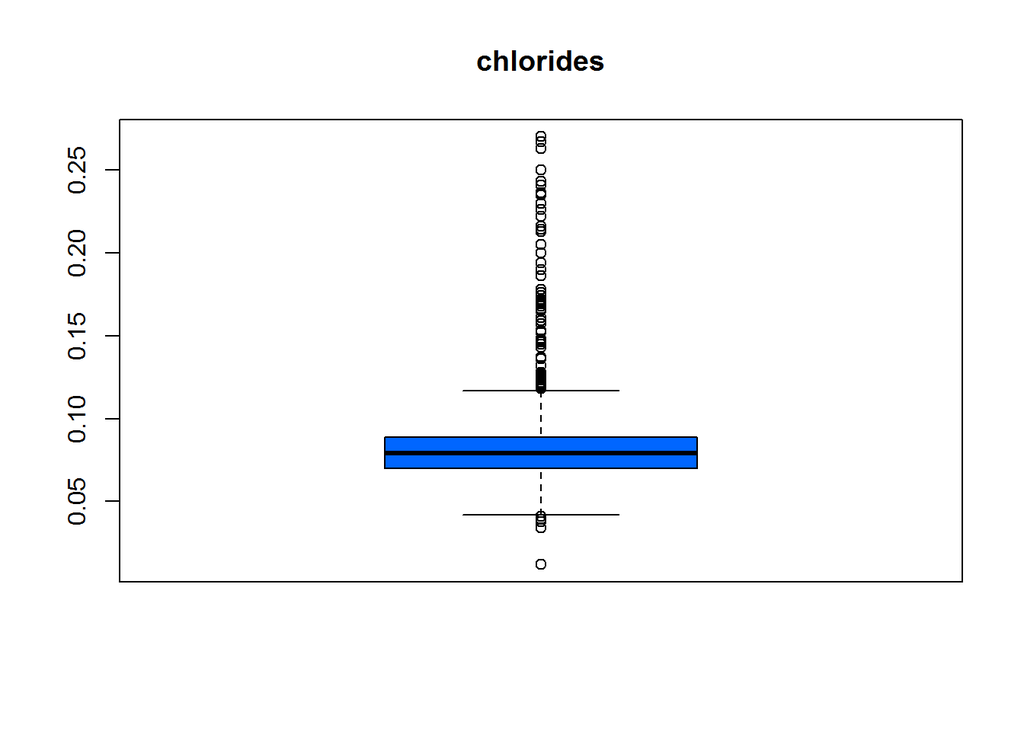

```r
boxplot(data$chlorides, main="chlorides", col=(c("#0066FF")))
```

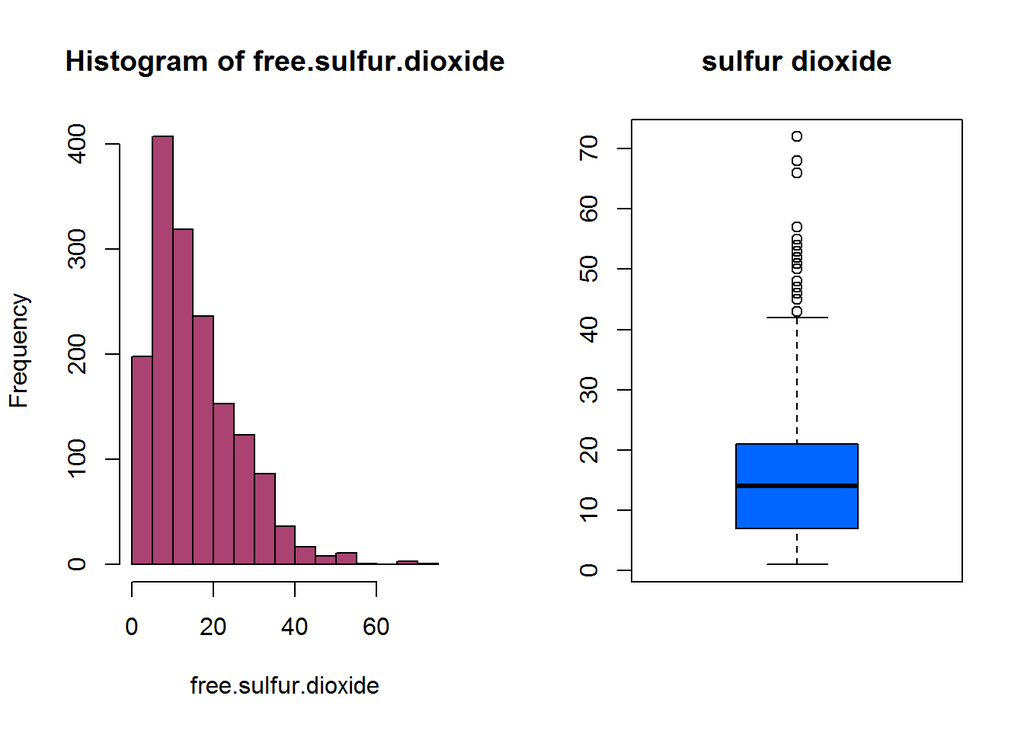

```r
par(mfrow=c(1,2))    # set the plotting area into a 1*2 array
hist(free.sulfur.dioxide, col=(c("#AA4371")))
boxplot(free.sulfur.dioxide, main="sulfur dioxide", col=(c("#0066FF")))
```

Vamos a considerar outliers los valores por encima de 60. A estas observaciones se les asignará el valor de la mediana.

```r
#asignamos el valor NA a los casos que van a ser considerados outliers
data$free.sulfur.dioxide[data$free.sulfur.dioxide>60 ] <- NA
idx <- which(is.na(data$free.sulfur.dioxide))
length(idx) #número de valores perdidos
```

```
## [1] 4
```

```r
#Imputamos el valor de la mediana a los valores NA.
for (i in 1:length(idx)){
index <- idx[i]
data[index,]$free.sulfur.dioxide <- median( data$free.sulfur.dioxide, na.rm=TRUE ) #imputación
}
```

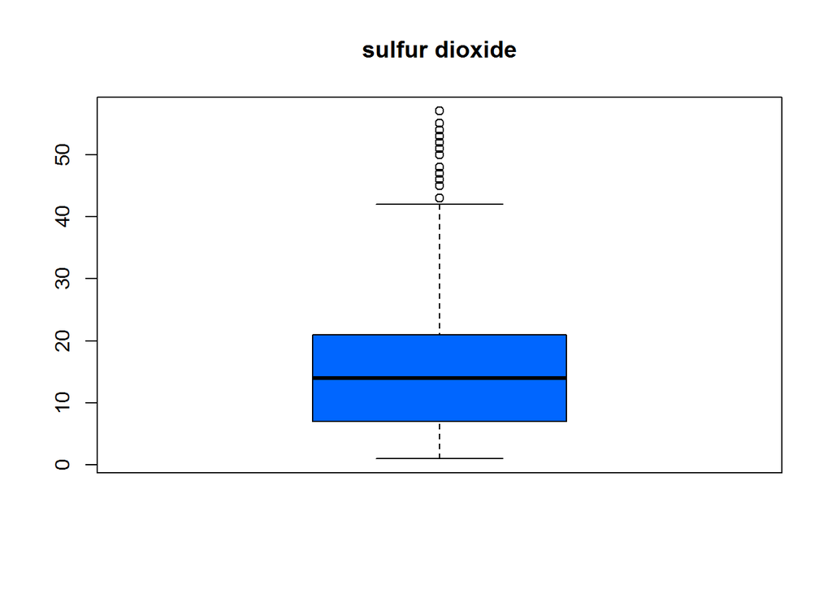

```r
boxplot(data$free.sulfur.dioxide, main="sulfur dioxide", col=(c("#0066FF")))
```

Revisamos que ya no exsistan valores por encima de 60 en esta variable.

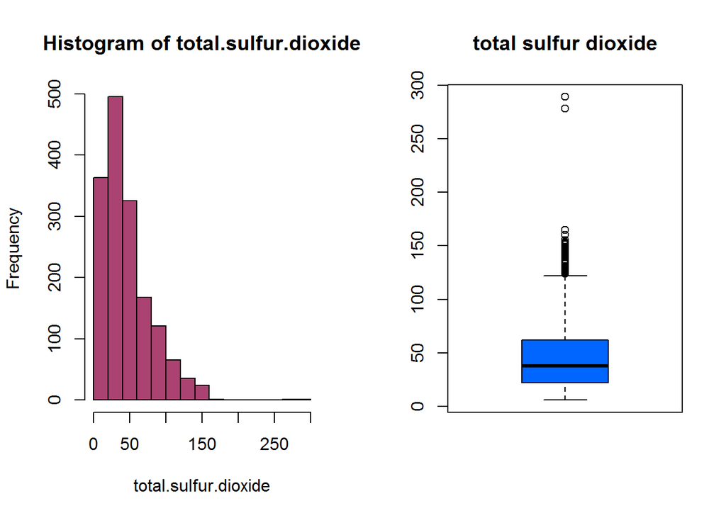

```r
par(mfrow=c(1,2))    # set the plotting area into a 1*2 array
hist(total.sulfur.dioxide, col=(c("#AA4371")))
boxplot(total.sulfur.dioxide, main="total sulfur dioxide", col=(c("#0066FF")))
```

Vamos a considerar outliers los valores por encima de 170. A estas observaciones se les asignará el valor de la mediana.

```r
#asignamos el valor NA a los casos que van a ser considerados outliers
data$total.sulfur.dioxide[data$total.sulfur.dioxide>170 ] <- NA
idx <- which(is.na(data$total.sulfur.dioxide))
length(idx) #número de valores perdidos
```

```
## [1] 2
```

```r
#Imputamos el valor de la mediana a los valores NA.
for (i in 1:length(idx)){
index <- idx[i]
data[index,]$total.sulfur.dioxide <- median( data$total.sulfur.dioxide, na.rm=TRUE ) #imputación
}
```

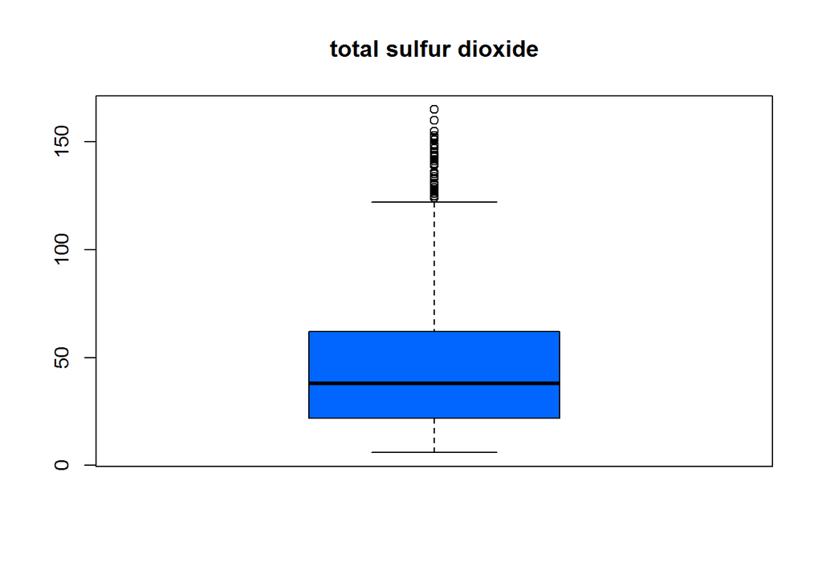

```r
boxplot(data$total.sulfur.dioxide, main="total sulfur dioxide", col=(c("#0066FF")))
```

Comprobamos que ya no exiten valores por encima de 170.

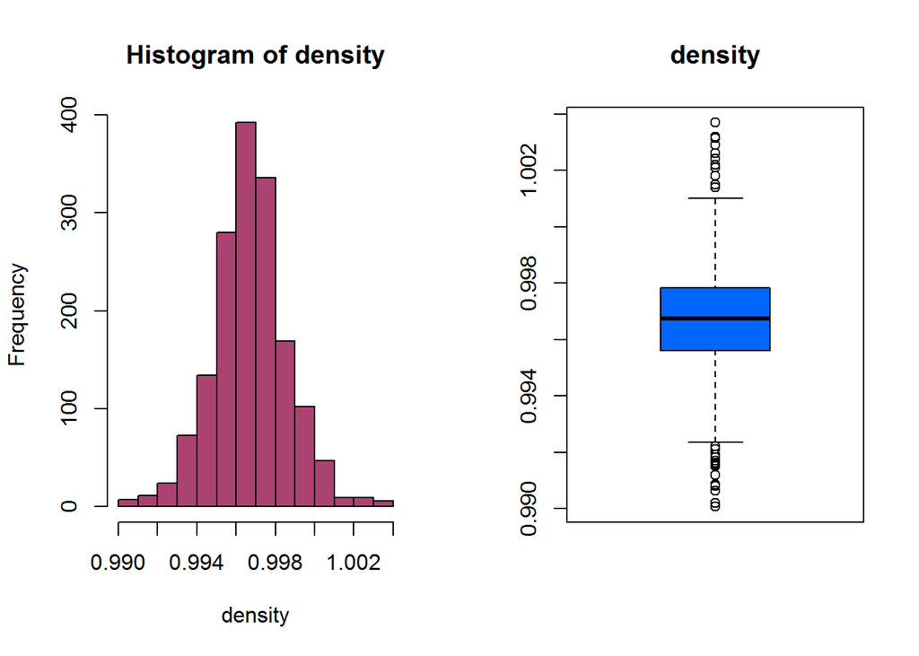

```r
par(mfrow=c(1,2))    # set the plotting area into a 1*2 array
hist(density, col=(c("#AA4371")))
boxplot(density, main="density", col=(c("#0066FF")))
```

En la Variable “density” se entiende que las observaciones pueden ser valores reales y que estan correctamente informadas. De lo anterior no aplicaremos transformaciones para estos datos.

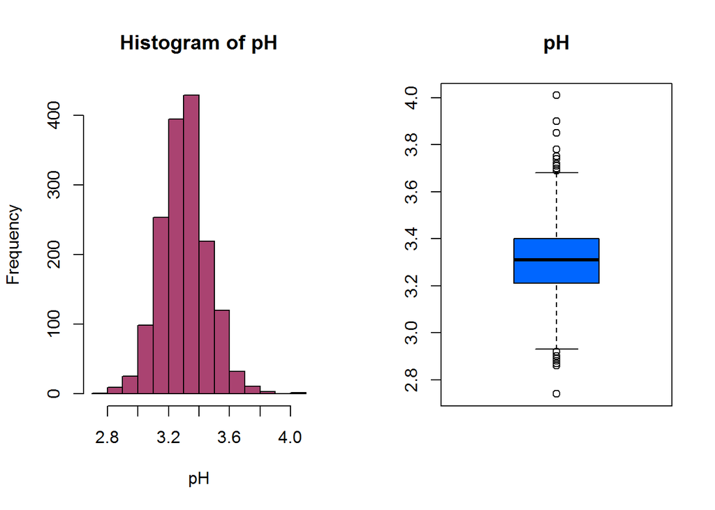

```r
par(mfrow=c(1,2))    # set the plotting area into a 1*2 array
hist(pH, col=(c("#AA4371")))
boxplot(pH, main="pH", col=(c("#0066FF")))
```

En la Variable “ph” se entiende que las observaciones pueden ser valores reales y que están correctamente informados. De lo anterior no aplicaremos transformaciones para estos datos.

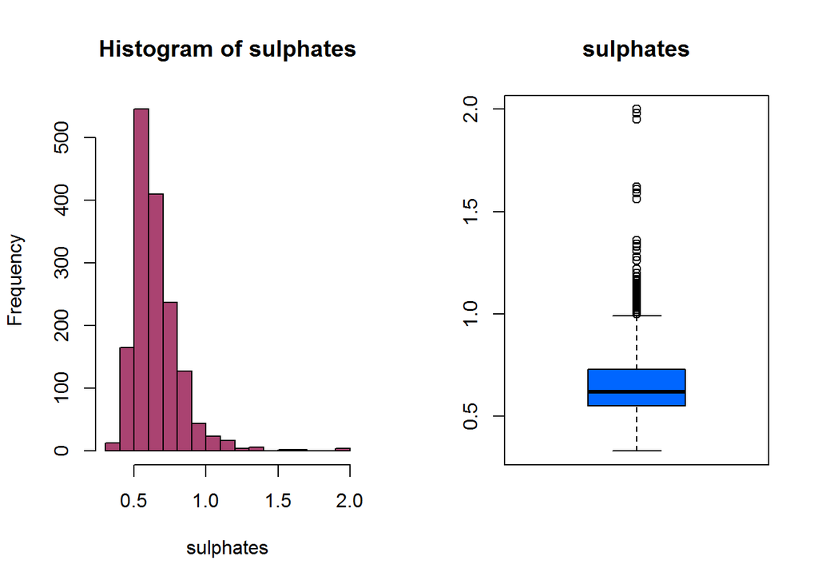

```r
par(mfrow=c(1,2))    # set the plotting area into a 1*2 array
hist(sulphates, col=(c("#AA4371")))
boxplot(sulphates, main="sulphates", col=(c("#0066FF")))
```

Vamos a considerar outliers los valores por encima de 1,5. A estas observaciones se les asignará el valor de la mediana.

```r
#asignamos el valor NA a los casos que van a ser considerados outliers
data$sulphates[data$sulphates>1.5 ] <- NA

idx <- which(is.na(data$sulphates))
length(idx) #número de valores perdidos
```

```
## [1] 8
```

```r
#Imputamos el valor de la mediana a los valores NA.
for (i in 1:length(idx)){
index <- idx[i]
data[index,]$sulphates <- median( data$sulphates, na.rm=TRUE ) #imputación
}
```

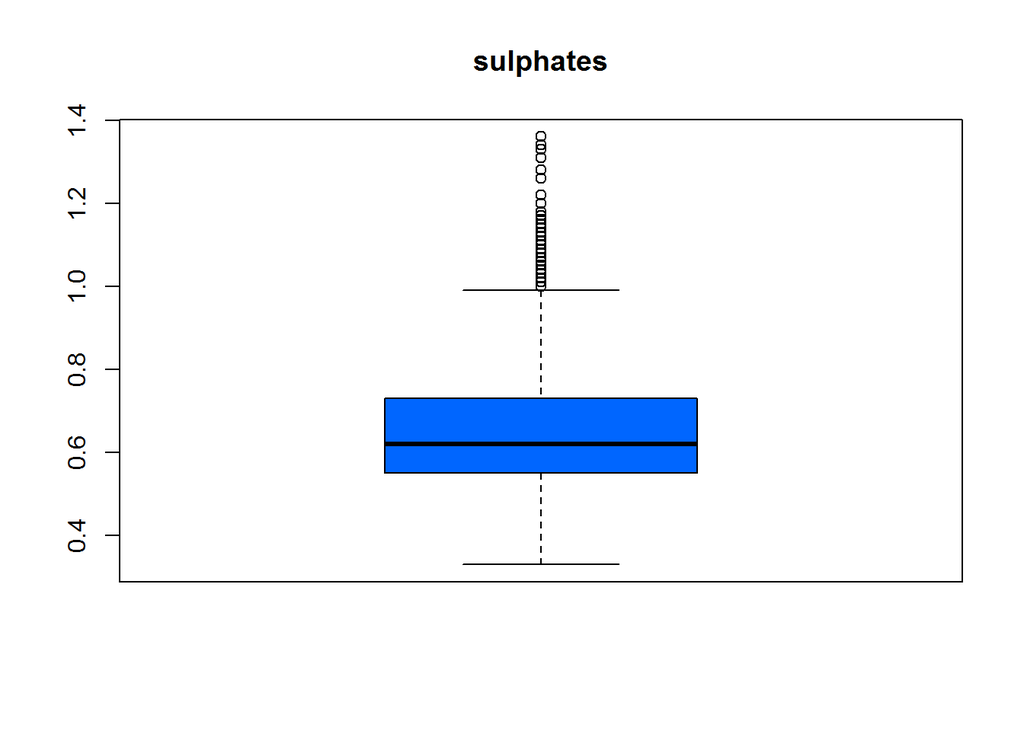

```r
boxplot(data$sulphates, main="sulphates", col=(c("#0066FF")))
```

Comprobamos que ya no exisnte valores por encima de 1,5

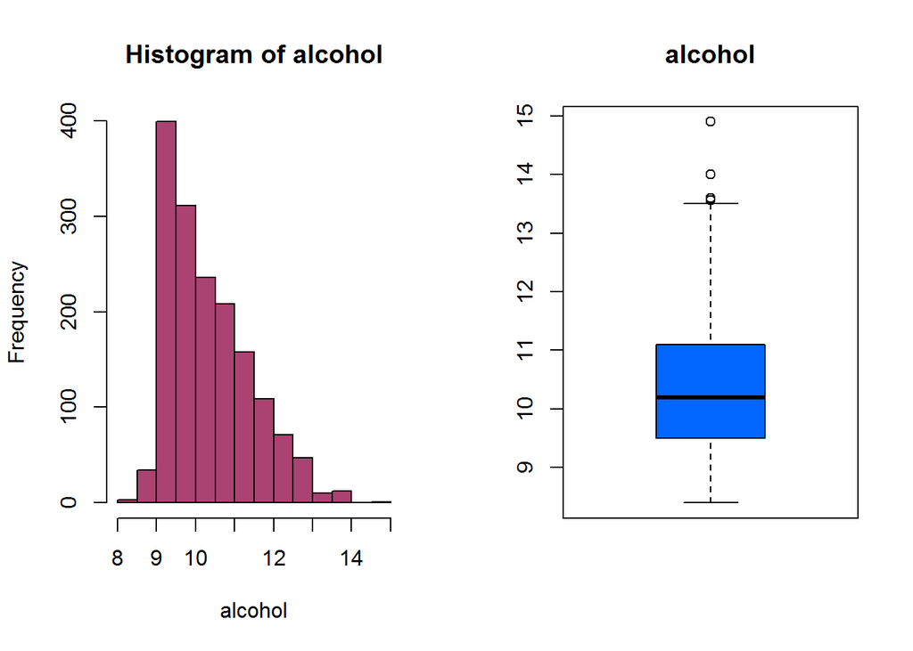

```r
par(mfrow=c(1,2))    # set the plotting area into a 1*2 array
hist(alcohol, col=(c("#AA4371")))
boxplot(alcohol, main="alcohol", col=(c("#0066FF")))
```

En la Variable “alcohol” se entiende que las observaciones pueden ser valores reales y que están correctamente informadas. De lo anterior no aplicaremos transformaciones para estos datos.

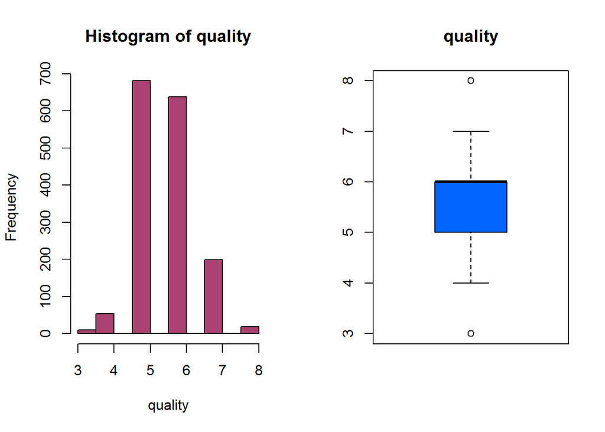

```r
par(mfrow=c(1,2))    # set the plotting area into a 1*2 array
hist(quality, col=(c("#AA4371")))
boxplot(quality, main="quality", col=(c("#0066FF")))
```

```r
###podemos considerarla categoricas
```

### Conclusiones de los criterios adoptados:

residual.sugar: se decide que los valores por encima de 10 van a ser considerados outliers. chlorides: se decide considerar outliers a los valores superiores a 0,3 free.sulfur.dioxide: se decide considerar outliers los valores por encima de 60. total.sulfur.dioxide: se considerar outliers los valores por encima de 170. sulphates: se decide considerar outliers los valores por encima de 1,5.

A todos esos casos se ha decidido imputar el valor de la mediana, exluidos los casos considerados outliers.  
En el resto de variables. no se han realizado modificaciones de los datos.

## 4. Análisis de los datos.

### 4.1. Selección de los grupos de datos que se quieren analizar/comparar (planificación de los análisis a aplicar).

```r
vinos.calidadAlta <- data[data$quality >= 7,]
#Se obtienen 217 observaciones
NROW(vinos.calidadAlta)
```

```
## [1] 217
```

```r
#En términos porcentuales supone un 13,57%
NROW(vinos.calidadAlta)/NROW(data)
```

```
## [1] 0.1357098
```

Existen 217 muestras cuyos valores de la variable quality es igual o superior a 7, lo que supone un 13,57% sobre el total del dataset.

### 4.2. Comprobación de la normalidad y homogeneidad de la varianza.

Indicar que por el teorema del límite central, podemos asumir normalidad, puesto que tenemos una muestra de tamaño grande n=1600 observaciones y se desea realizar un test sobre la media.

Analizamos la normalidad la variables con el ad.test de la libreria nortest.

```r
#install.packages("nortest")
library(nortest)
alpha = 0.05
col.names = colnames(data)
for (i in 1:ncol(data)) {
if (i == 1) cat("Variables que no siguen una distribución normal:\n")
if (is.integer(data[,i]) | is.numeric(data[,i])) {
p_val = ad.test(data[,i])$p.value
if (p_val < alpha) {
cat(col.names[i])
# Format output
if (i < ncol(data) - 1) cat("\n")
if (i %% 3 == 0) cat("")
}
}
}
```

```
## Variables que no siguen una distribución normal:
## fixed.acidity
## volatile.acidity
## citric.acid
## residual.sugar
## chlorides
## free.sulfur.dioxide
## total.sulfur.dioxide
## density
## pH
## sulphates
## alcoholquality
```

Analizamos la normalidad con el ‘density plot’ y el ‘qqplot’

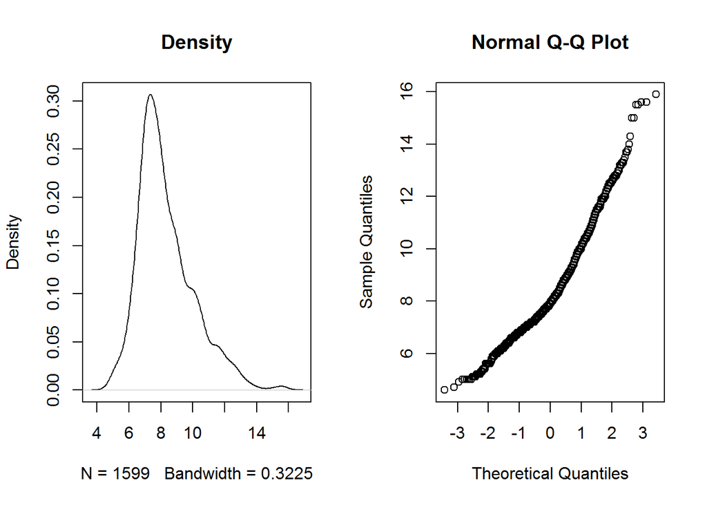

```r
par(mfrow=c(1,2))
plot(density(fixed.acidity),main="Density")
qqnorm(fixed.acidity)
```

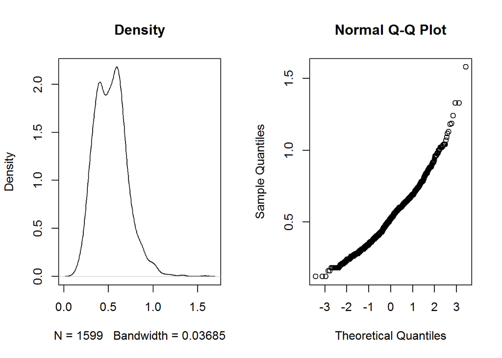

```r
par(mfrow=c(1,2))
plot(density(volatile.acidity),main="Density")
qqnorm(volatile.acidity)
```

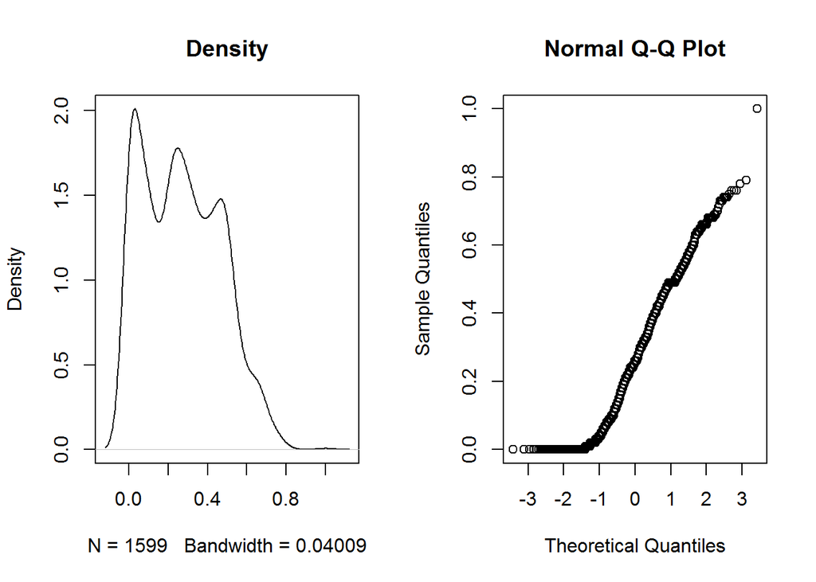

```r
par(mfrow=c(1,2))
plot(density(citric.acid),main="Density")
qqnorm(citric.acid)
```

citric.acid: su extremo izquierdo se desvía de la normal observando el grafico : q-q

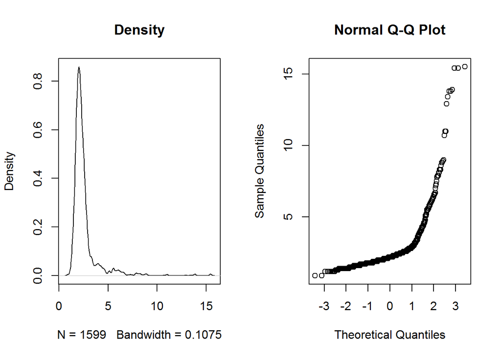

```r
par(mfrow=c(1,2))
plot(density(residual.sugar),main="Density")
qqnorm(residual.sugar)
```

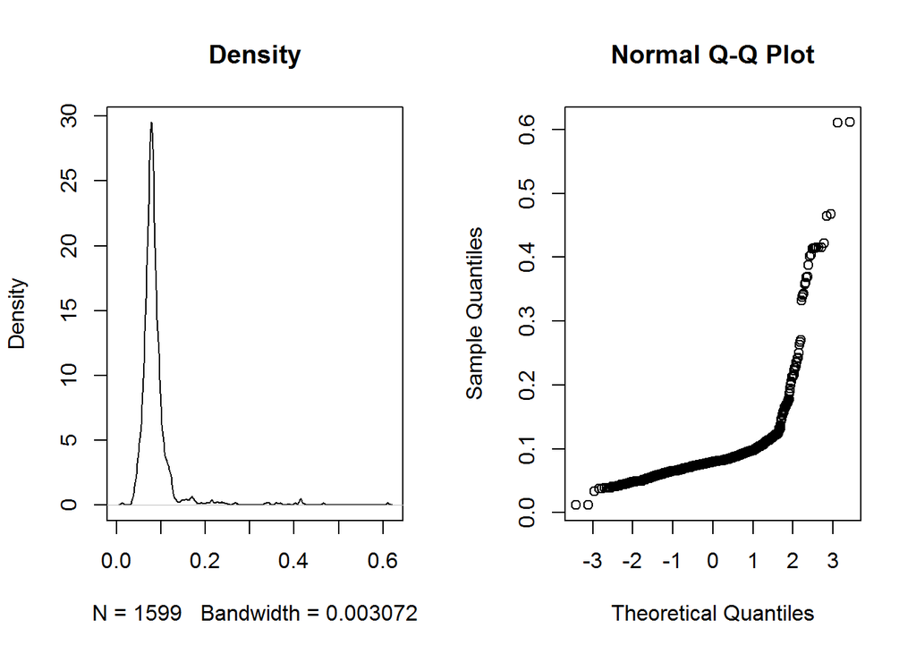

```r
par(mfrow=c(1,2))
plot(density(chlorides),main="Density")
qqnorm(chlorides)
```

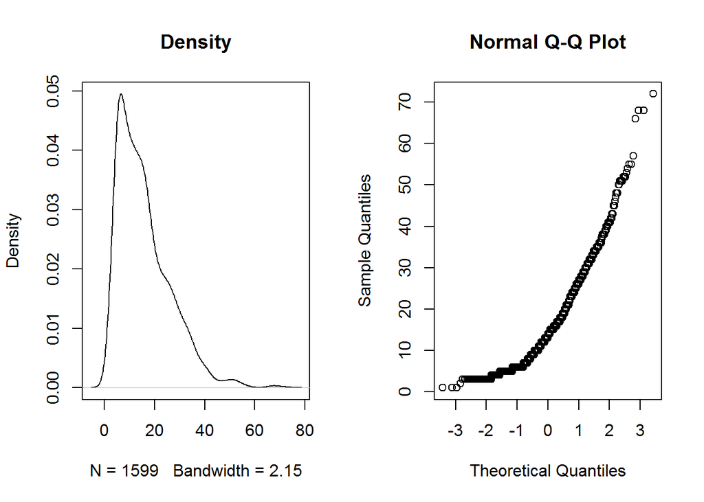

```r
par(mfrow=c(1,2))
plot(density(free.sulfur.dioxide),main="Density")
qqnorm(free.sulfur.dioxide)
```

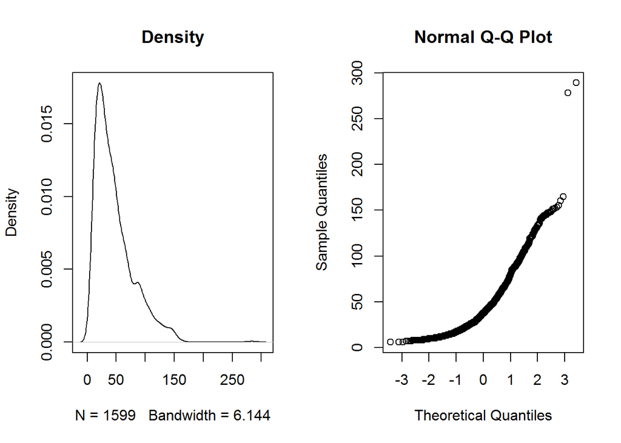

```r
par(mfrow=c(1,2))
plot(density(total.sulfur.dioxide),main="Density")
qqnorm(total.sulfur.dioxide)
```

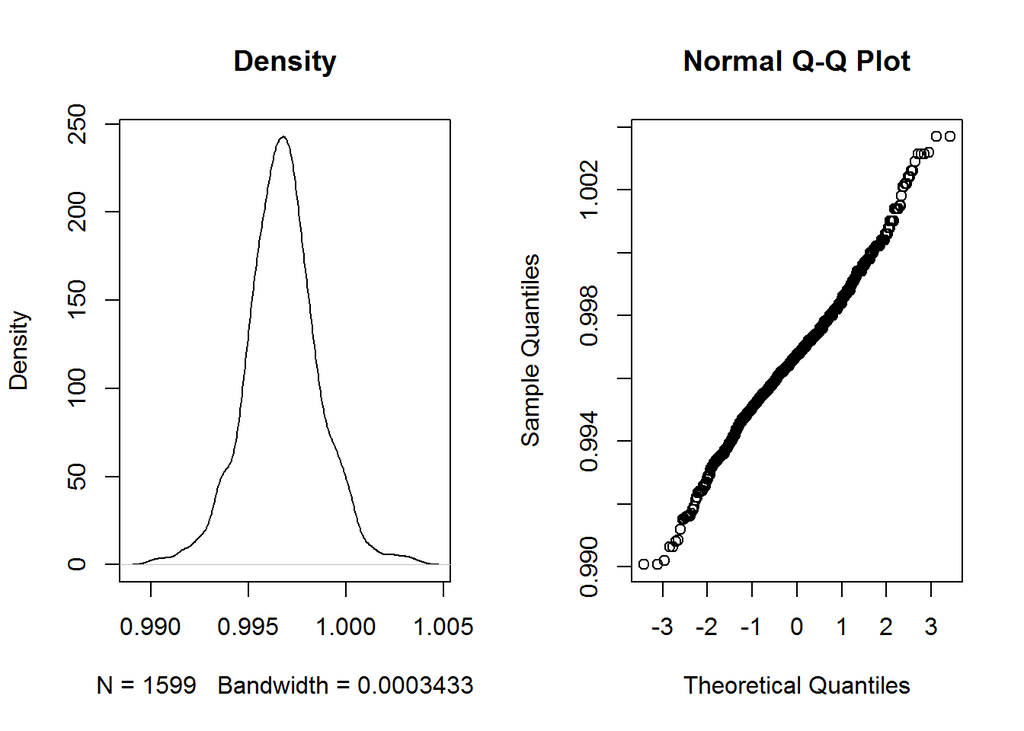

```r
par(mfrow=c(1,2))
plot(density(density),main="Density")
qqnorm(density)
```

density(density , parece seguir una distribución normal observando el grafico : q-q

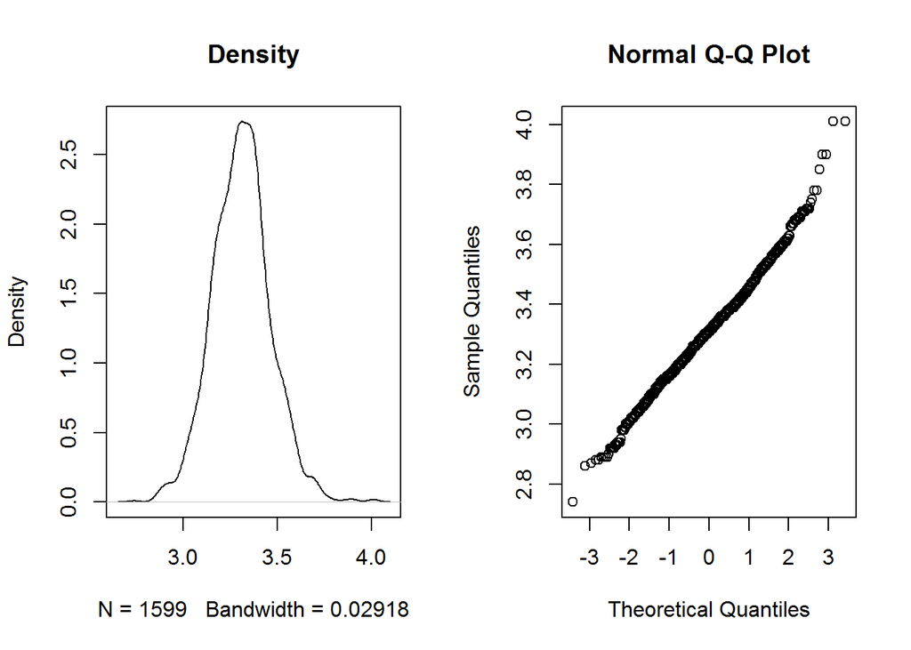

```r
par(mfrow=c(1,2))
plot(density(pH),main="Density")
qqnorm(pH)
```

density(pH): parece seguir una distribución normal observando el grafico : q-q

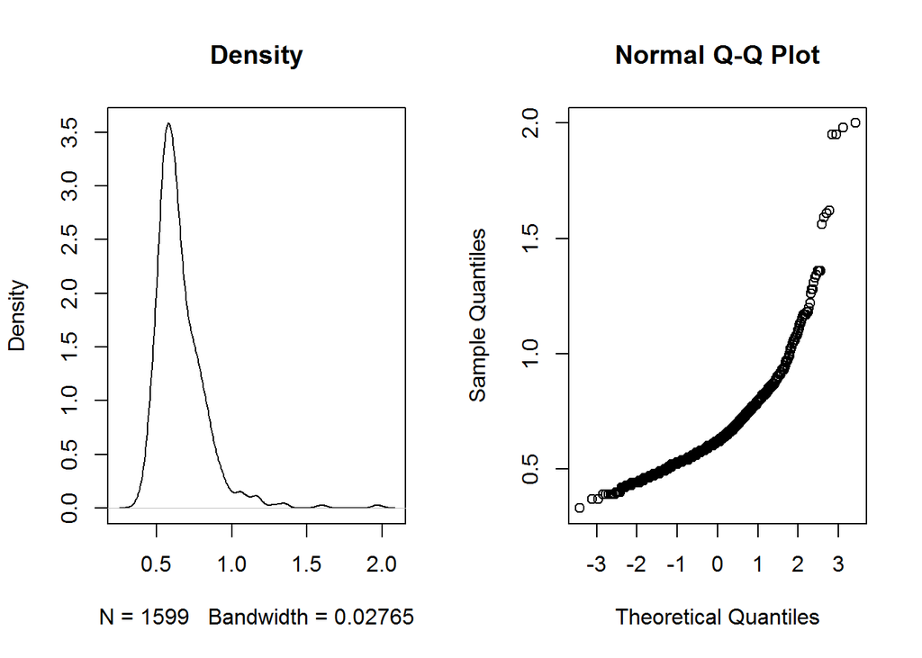

```r
par(mfrow=c(1,2))
plot(density(sulphates),main="Density")
qqnorm(sulphates)
```

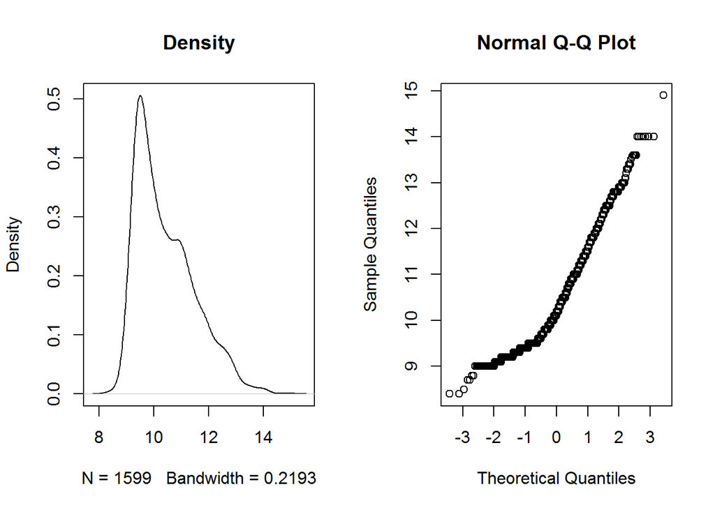

```r
par(mfrow=c(1,2))
plot(density(alcohol),main="Density")
qqnorm(alcohol)
```

Seguidamente, pasamos a estudiar la homogeneidad de varianzas mediante la aplicación de un test de Fligner-Killeen. En este caso, estudiaremos esta homogeneidad. En el siguiente test, la hipótesis nula consiste en que ambas varianzas son iguales.

```r
fligner.test(quality ~ residual.sugar, data = data)
```

```
##
##  Fligner-Killeen test of homogeneity of variances
##
## data:  quality by residual.sugar
## Fligner-Killeen:med chi-squared = 75.977, df = 82, p-value = 0.6664
```

Puesto que obtenemos un p-valor superior a 0,05, aceptamos la hipótesis de que las varianzas de ambas muestras son homogéneas.

### 4.3. Aplicación de pruebas estadísticas para comparar los grupos de datos. En función de los datos y el objetivo del estudio, aplicar pruebas de contraste de hipótesis, correlaciones, regresiones, etc. Aplicar al menos tres métodos de análisis diferentes.

```r
summary(alcohol)
```

```
##    Min. 1st Qu.  Median    Mean 3rd Qu.    Max.
##    8.40    9.50   10.20   10.42   11.10   14.90
```

Contraste de hipótesis:

Se aplica la prueba estadistica de contraste de hipótesis sobre dos muestras para determinar si el nivel de calidad el vino es diferente dependiendo de la categoría calculada en función del alcohol. Se considera nivel bajo de alcohol las muestras con un valor por debajo de la media (10.42) y nivel alto cuando la muestra tiene un valor superior o igual a 10.42.

Para ello, tendremos dos categorias: - Vinos con nivel bajo de alcohol - Vinos con nivel alto de alcohol

```r
data_AlcoholBajo <- data[data$alcohol < 10.42,]$quality
data_AlcoholAlto <- data[data$alcohol >= 10.42,]$quality
```

Nos preguntamos si la calidad del los vinos puede ser diferente en función de la categoría creada en función del grado de alcohol de la muestras. (anteriormente descrita)

En este escenario la hipótesis nula y la alternativa.

H0 : μAlcBajo = μAlcAlto H1 : μAlcBajo =! μAlcAlto

Es un test de dos muestras sobre la media con varianzas desconocidas. Por el teorema del límite central, podemos asumir normalidad. Comprobamos igualdad de varianzas:

```r
var.test( data_AlcoholBajo, data_AlcoholAlto )
```

```
##
##  F test to compare two variances
##
## data:  data_AlcoholBajo and data_AlcoholAlto
## F = 0.59219, num df = 915, denom df = 682, p-value = 1.624e-13
## alternative hypothesis: true ratio of variances is not equal to 1
## 95 percent confidence interval:
##  0.5142841 0.6809068
## sample estimates:
## ratio of variances
##          0.5921906
```

El resultado del test es un valor p<0.05. Por tanto, asumimos diferencias de varianzas. En consecuencia, el test se corresponde con un test de dos muestras independientes sobre la media con varianzas desconocidas diferentes. El test es bilateral.

```r
t.test( data_AlcoholBajo, data_AlcoholAlto,
var.equal=FALSE, alternative="two.sided")
```

```
##
##  Welch Two Sample t-test
##
## data:  data_AlcoholBajo and data_AlcoholAlto
## t = -17.688, df = 1237.4, p-value < 2.2e-16
## alternative hypothesis: true difference in means is not equal to 0
## 95 percent confidence interval:
##  -0.7569536 -0.6057987
## sample estimates:
## mean of x mean of y
##  5.344978  6.026354
```

Conclusión: Nos encontramos con un p-value por debajo de 0.05 por lo que podemos indicar que podemos aceptar la hipótesis alternativa. Podemos indicar que la calidad de los vinos es diferente entre los considerados como nivel bajo de alcohol y los vinos con un nivel alto de alcohol con un nivel de confianza del 95%.

```r
#install.packages("ggplot2")
```

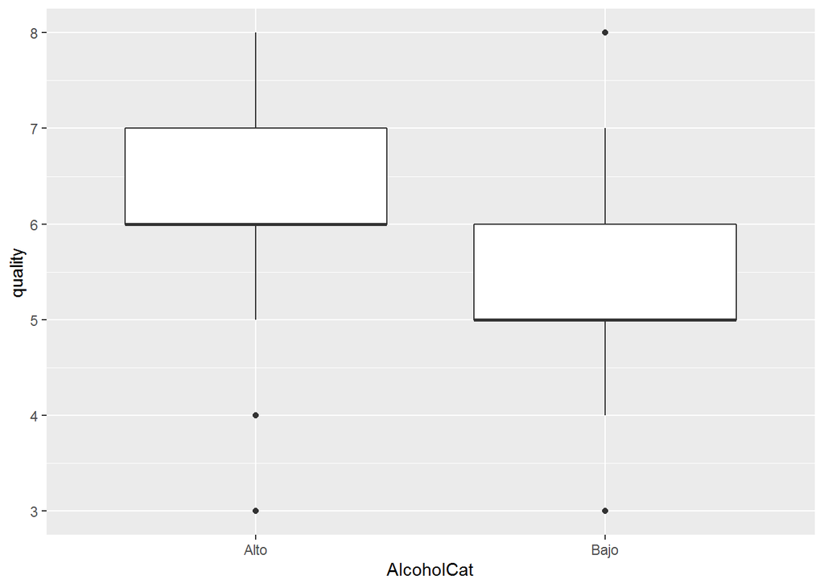

```r
library("ggplot2")
data$AlcoholCat <- ifelse(data$alcohol < 10.42 , "Bajo", "Alto")
 #diagramas de caja:  distribucion de la variable ‘Weight‘ según la variable ‘portero‘
  ggplot(data =data, aes(x=AlcoholCat,y=quality)) + geom_boxplot()
```

Representación gráfica del nivel de calidad frente a la categorías realizadas en función de las variables de alcohol consideradas.

Análisis de la correlación.

```r
corr_matrix <- matrix(nc = 2, nr = 0)
colnames(corr_matrix) <- c("estimate", "p-value")
```

```r
# Calcular el coeficiente de correlación para cada variable cuantitativa
# con respecto al campo "quality"
for (i in 1:(ncol(data) - 1)) {
if (is.integer(data[,i]) | is.numeric(data[,i])) {
spearman_test = cor.test(data[,i],data$quality,method = "spearman")
corr_coef = spearman_test$estimate
p_val = spearman_test$p.value
# Add row to matrix
pair = matrix(ncol = 2, nrow = 1)
pair[1][1] = corr_coef
pair[2][1] = p_val
corr_matrix <- rbind(corr_matrix, pair)
rownames(corr_matrix)[nrow(corr_matrix)] <- colnames(data)[i]
}
}
```

[output not shown]

```r
corr_matrix
```

```
##                         estimate      p-value
## fixed.acidity         0.11408367 4.801220e-06
## volatile.acidity     -0.38064651 2.734944e-56
## citric.acid           0.21348091 6.158952e-18
## residual.sugar        0.03270283 1.912021e-01
## chlorides            -0.18332346 1.494955e-13
## free.sulfur.dioxide  -0.05485346 2.827937e-02
## total.sulfur.dioxide -0.20048430 5.826244e-16
## density              -0.17707407 9.918139e-13
## pH                   -0.04367193 8.084594e-02
## sulphates             0.38395957 2.537306e-57
## alcohol               0.47853169 2.726838e-92
## quality               1.00000000 0.000000e+00
```

Así, identificamos cuáles son las variables más correlacionadas con la calidad del vino en función de su proximidad con los valores -1 y +1. Teniendo esto en cuenta, queda patente cómo la variable más relevante en la calidad del vino es el alcohol . Nota. Para cada coeficiente de correlación se muestra también su p-valor asociado, puesto que éste puede dar información acerca del peso estadístico de la correlación obtenida.

Correlacion con la variable Quality:

```r
corr.res<-cor(data[,-13], method="spearman")
corr.res
```

```
##                      fixed.acidity volatile.acidity  citric.acid residual.sugar
## fixed.acidity           1.00000000      -0.27828222  0.661708417     0.22061984
## volatile.acidity       -0.27828222       1.00000000 -0.610259467     0.03838806
## citric.acid             0.66170842      -0.61025947  1.000000000     0.17281554
## residual.sugar          0.22061984       0.03838806  0.172815538     1.00000000
## chlorides               0.24948756       0.16292441  0.085052679     0.23681569
## free.sulfur.dioxide    -0.17026090       0.01908994 -0.074407514     0.06093500
## total.sulfur.dioxide   -0.08851961       0.09732612  0.005880251     0.13128825
## density                 0.62307076       0.02501412  0.352285261     0.41263833
## pH                     -0.70667359       0.23357152 -0.548026276    -0.08406679
## sulphates               0.21263218      -0.32845414  0.329490517     0.04180563
## alcohol                -0.06657566      -0.22493168  0.096455544     0.12950596
## quality                 0.11408367      -0.38064651  0.213480914     0.03270283
##                         chlorides free.sulfur.dioxide total.sulfur.dioxide
## fixed.acidity         0.249487559        -0.170260896         -0.088519608
## volatile.acidity      0.162924412         0.019089943          0.097326120
## citric.acid           0.085052679        -0.074407514          0.005880251
## residual.sugar        0.236815693         0.060935002          0.131288245
## chlorides             1.000000000        -0.005331721          0.128941252
## free.sulfur.dioxide  -0.005331721         1.000000000          0.783791037
## total.sulfur.dioxide  0.128941252         0.783791037          1.000000000
## density               0.414069187        -0.045902592          0.133054752
## pH                   -0.204374649         0.114175693         -0.006302514
## sulphates            -0.022873613         0.044009451         -0.008090304
## alcohol              -0.261929083        -0.080067784         -0.261431180
## quality              -0.183323461        -0.054853464         -0.200484301
##                          density           pH    sulphates     alcohol
## fixed.acidity         0.62307076 -0.706673595  0.212632177 -0.06657566
## volatile.acidity      0.02501412  0.233571519 -0.328454141 -0.22493168
## citric.acid           0.35228526 -0.548026276  0.329490517  0.09645554
## residual.sugar        0.41263833 -0.084066795  0.041805632  0.12950596
## chlorides             0.41406919 -0.204374649 -0.022873613 -0.26192908
## free.sulfur.dioxide  -0.04590259  0.114175693  0.044009451 -0.08006778
## total.sulfur.dioxide  0.13305475 -0.006302514 -0.008090304 -0.26143118
## density               1.00000000 -0.312055078  0.159942063 -0.46244458
## pH                   -0.31205508  1.000000000 -0.067479602  0.17993243
## sulphates             0.15994206 -0.067479602  1.000000000  0.21641153
## alcohol              -0.46244458  0.179932427  0.216411535  1.00000000
## quality              -0.17707407 -0.043671935  0.383959571  0.47853169
##                          quality
## fixed.acidity         0.11408367
## volatile.acidity     -0.38064651
## citric.acid           0.21348091
## residual.sugar        0.03270283
## chlorides            -0.18332346
## free.sulfur.dioxide  -0.05485346
## total.sulfur.dioxide -0.20048430
## density              -0.17707407
## pH                   -0.04367193
## sulphates             0.38395957
## alcohol               0.47853169
## quality               1.00000000
```

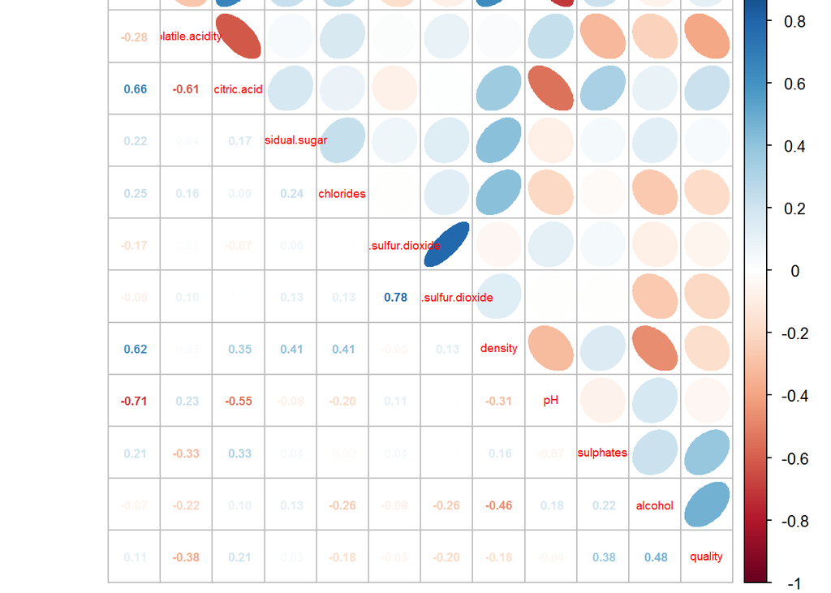

```r
#install.packages("corrplot")
#library(corrplot)
corrplot::corrplot.mixed(corr.res, upper="ellipse",number.cex=.6,tl.cex=.6)
```

Se analiza adicionalmente la correlación de forma gráfica.

```r
#par(mfrow = c(1,1))
#cor.data <- cor(data)
#corrplot(cor.data, method = 'number')
```

Se pueden apreciar relaciones débiles entre residual sugar, free sulfur dioxide, ph, fixed acidity y density.

Modelo de regresión lineal:

Incialmente realizamos un modelo lineal con las 4 variables mas correlacionadas con la variable “quality”

```r
modelo1 <- lm(quality ~ alcohol +volatile.acidity + sulphates + citric.acid )
summary(modelo1)
```

```
##
## Call:
## lm(formula = quality ~ alcohol + volatile.acidity + sulphates +
##     citric.acid)
##
## Residuals:
##      Min       1Q   Median       3Q      Max
## -2.71408 -0.38590 -0.06402  0.46657  2.20393
##
## Coefficients:
##                  Estimate Std. Error t value Pr(>|t|)
## (Intercept)       2.64592    0.20106  13.160  < 2e-16 ***
## alcohol           0.30908    0.01581  19.553  < 2e-16 ***
## volatile.acidity -1.26506    0.11266 -11.229  < 2e-16 ***
## sulphates         0.69552    0.10311   6.746 2.12e-11 ***
## citric.acid      -0.07913    0.10381  -0.762    0.446
## ---
## Signif. codes:  0 '***' 0.001 '**' 0.01 '*' 0.05 '.' 0.1 ' ' 1
##
## Residual standard error: 0.6588 on 1594 degrees of freedom
## Multiple R-squared:  0.3361, Adjusted R-squared:  0.3345
## F-statistic: 201.8 on 4 and 1594 DF,  p-value: < 2.2e-16
```

Posteriormente realizamos un modelo lineal con las 5 variables más correlacionadas con la variable “quality” (simplemente añadimos total sulfur dioxide al modelo anterior)

```r
# Intervalos de confianza
confint(modelo1)
```

```
##                       2.5 %     97.5 %
## (Intercept)       2.2515575  3.0402782
## alcohol           0.2780728  0.3400835
## volatile.acidity -1.4860436 -1.0440733
## sulphates         0.4932780  0.8977542
## citric.acid      -0.2827462  0.1244961
```

```r
# En caso de querer los intervalos basados en el error estándar.
confint.default(modelo1)
```

```
##                       2.5 %     97.5 %
## (Intercept)       2.2518569  3.0399788
## alcohol           0.2780963  0.3400600
## volatile.acidity -1.4858758 -1.0442411
## sulphates         0.4934316  0.8976006
## citric.acid      -0.2825916  0.1243415
```

```r
modelo2 <- lm(quality ~ alcohol +volatile.acidity + sulphates + citric.acid + total.sulfur.dioxide)
summary(modelo2)
```

```
##
## Call:
## lm(formula = quality ~ alcohol + volatile.acidity + sulphates +
##     citric.acid + total.sulfur.dioxide)
##
## Residuals:
##      Min       1Q   Median       3Q      Max
## -2.72463 -0.38380 -0.06689  0.44606  2.14550
##
## Coefficients:
##                        Estimate Std. Error t value Pr(>|t|)
## (Intercept)           2.8431068  0.2050732  13.864  < 2e-16 ***
## alcohol               0.2953419  0.0160375  18.416  < 2e-16 ***
## volatile.acidity     -1.2223102  0.1124774 -10.867  < 2e-16 ***
## sulphates             0.7207881  0.1027039   7.018 3.32e-12 ***
## citric.acid          -0.0427246  0.1035810  -0.412     0.68
## total.sulfur.dioxide -0.0022182  0.0005126  -4.327 1.60e-05 ***
## ---
## Signif. codes:  0 '***' 0.001 '**' 0.01 '*' 0.05 '.' 0.1 ' ' 1
##
## Residual standard error: 0.6552 on 1593 degrees of freedom
## Multiple R-squared:  0.3439, Adjusted R-squared:  0.3418
## F-statistic:   167 on 5 and 1593 DF,  p-value: < 2.2e-16
```

```r
# Intervalos de confianza
confint(modelo2)
```

```
##                             2.5 %       97.5 %
## (Intercept)           2.440865047  3.245348455
## alcohol               0.263885167  0.326798655
## volatile.acidity     -1.442929393 -1.001690996
## sulphates             0.519339183  0.922237030
## citric.acid          -0.245894093  0.160444848
## total.sulfur.dioxide -0.003223673 -0.001212781
```

```r
# En caso de querer los intervalos basados en el error estándar.
confint.default(modelo2)
```

```
##                             2.5 %       97.5 %
## (Intercept)           2.441170667  3.245042835
## alcohol               0.263909067  0.326774754
## volatile.acidity     -1.442761768 -1.001858621
## sulphates             0.519492243  0.922083970
## citric.acid          -0.245739727  0.160290481
## total.sulfur.dioxide -0.003222909 -0.001213545
```

```r
modelo3 <- lm(quality ~ alcohol +volatile.acidity + sulphates + citric.acid + chlorides +total.sulfur.dioxide +density)
summary(modelo3)
```

```
##
## Call:
## lm(formula = quality ~ alcohol + volatile.acidity + sulphates +
##     citric.acid + chlorides + total.sulfur.dioxide + density)
##
## Residuals:
##      Min       1Q   Median       3Q      Max
## -2.67819 -0.38067 -0.06311  0.44428  2.05461
##
## Coefficients:
##                        Estimate Std. Error t value Pr(>|t|)
## (Intercept)          -0.9529094 11.9896065  -0.079    0.937
## alcohol               0.2802878  0.0202744  13.825  < 2e-16 ***
## volatile.acidity     -1.1144889  0.1197464  -9.307  < 2e-16 ***
## sulphates             0.9025477  0.1122700   8.039 1.75e-15 ***
## citric.acid           0.0444070  0.1236454   0.359    0.720
## chlorides            -1.7474785  0.4056573  -4.308 1.75e-05 ***
## total.sulfur.dioxide -0.0023195  0.0005138  -4.514 6.82e-06 ***
## density               3.9230934 11.9441494   0.328    0.743
## ---
## Signif. codes:  0 '***' 0.001 '**' 0.01 '*' 0.05 '.' 0.1 ' ' 1
##
## Residual standard error: 0.6517 on 1591 degrees of freedom
## Multiple R-squared:  0.3517, Adjusted R-squared:  0.3488
## F-statistic: 123.3 on 7 and 1591 DF,  p-value: < 2.2e-16
```

Al revisar R-squared, se observa cómo al ir incluyendo más variables se mejora, aunque no mucho, la precisión del modelo.

```r
# Intervalos de confianza
confint(modelo3)
```

```
##                              2.5 %       97.5 %
## (Intercept)          -24.469996853 22.564178123
## alcohol                0.240520525  0.320055120
## volatile.acidity      -1.349366182 -0.879611611
## sulphates              0.682334966  1.122760383
## citric.acid           -0.198118011  0.286932040
## chlorides             -2.543157645 -0.951799434
## total.sulfur.dioxide  -0.003327297 -0.001311684
## density              -19.504831974 27.351018799
```

```r
# En caso de querer los intervalos basados en el error estándar.
confint.default(modelo3)
```

```
##                              2.5 %       97.5 %
## (Intercept)          -24.452106293 22.546287563
## alcohol                0.240550778  0.320024867
## volatile.acidity      -1.349187499 -0.879790293
## sulphates              0.682502492  1.122592856
## citric.acid           -0.197933511  0.286747540
## chlorides             -2.542552334 -0.952404745
## total.sulfur.dioxide  -0.003326531 -0.001312451
## density              -19.487009244 27.333196069
```

Regresion logistica:

Creamos una variable dicotómica para aplicar la regresión logistica. CalidadAlta será igual a 1 cuando los valores de la variable quality sean superiores o iguales a 6

```r
data$CalidadAlta <- ifelse( data$quality >=6 , 1, 0)
#revisamos los valores
table(data$quality, data$CalidadAlta)
```

```
##
##       0   1
##   3  10   0
##   4  53   0
##   5 681   0
##   6   0 638
##   7   0 199
##   8   0  18
```

Revisamos los valores introducidos en la nueva variable y su relación con el contenido en la variable “quality”

```r
model.logist1=glm(formula=CalidadAlta ~ alcohol +volatile.acidity +sulphates+citric.acid +chlorides+total.sulfur.dioxide,   data = data,family=binomial(link=logit))
summary(model.logist1)
```

```
##
## Call:
## glm(formula = CalidadAlta ~ alcohol + volatile.acidity + sulphates +
##     citric.acid + chlorides + total.sulfur.dioxide, family = binomial(link = logit),
##     data = data)
##
## Deviance Residuals:
##     Min       1Q   Median       3Q      Max
## -3.0992  -0.8477   0.3166   0.8562   2.3680
##
## Coefficients:
##                      Estimate Std. Error z value Pr(>|z|)
## (Intercept)          -8.48525    0.86548  -9.804  < 2e-16 ***
## alcohol               0.90564    0.07112  12.734  < 2e-16 ***
## volatile.acidity     -3.50967    0.45134  -7.776 7.48e-15 ***
## sulphates             2.91628    0.44170   6.602 4.05e-11 ***
## citric.acid          -0.89010    0.39249  -2.268   0.0233 *
## chlorides             0.50032    2.45127   0.204   0.8383
## total.sulfur.dioxide -0.01226    0.00205  -5.979 2.25e-09 ***
## ---
## Signif. codes:  0 '***' 0.001 '**' 0.01 '*' 0.05 '.' 0.1 ' ' 1
##
## (Dispersion parameter for binomial family taken to be 1)
##
##     Null deviance: 2209.0  on 1598  degrees of freedom
## Residual deviance: 1668.9  on 1592  degrees of freedom
## AIC: 1682.9
##
## Number of Fisher Scoring iterations: 4
```

## 5. Representación de los resultados a partir de tablas y gráficas.

Relativo al contraste de hipotesis, podemos observar:

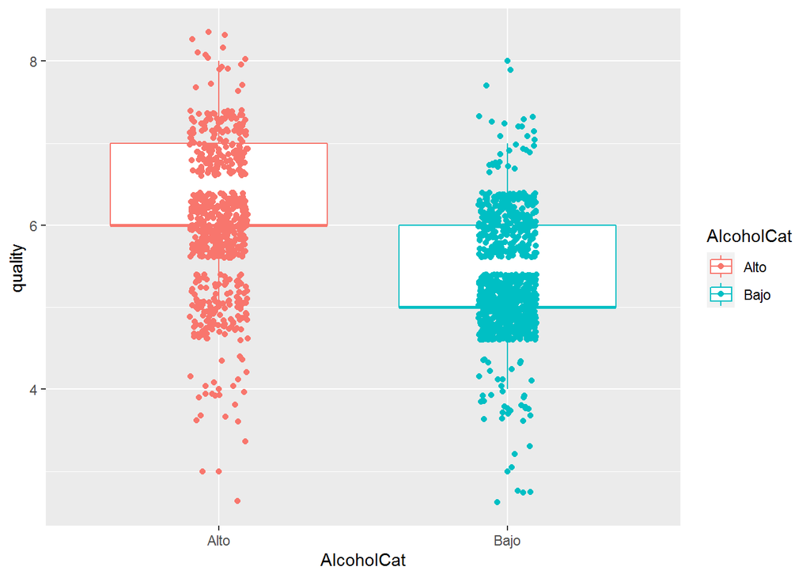

```r
library("ggplot2")
data$AlcoholCat <- ifelse(data$alcohol < 10.42 , "Bajo", "Alto")
  ggplot(data =data, aes(x=AlcoholCat,y=quality, color = AlcoholCat )) + geom_boxplot() +
  geom_jitter(width = 0.1)
```

Esta representaación nos ayuda a observar fácilmente que existe una diferencia notoria entre el grado de alcohol alto o bajo en relación con la calidad. Podemos observar que para las muestras consideradas nivel de alcohol Alto, se obtiene un valor de quality superior a la quality de las muestras consideras nivel bajo de alcohol.

Visualizamos los datos asociados a cada modelo, en especial el grafico Normal Q-Q y el gráfico de residuos frente valores ajustados,

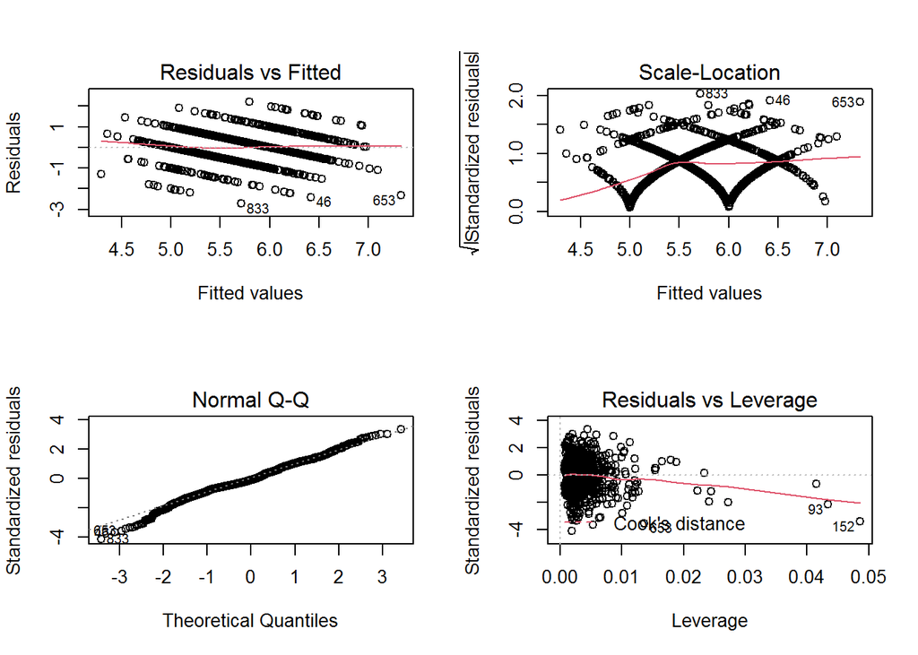

```r
layout(matrix(c(1,2,3,4),2,2))
plot(modelo1)
```

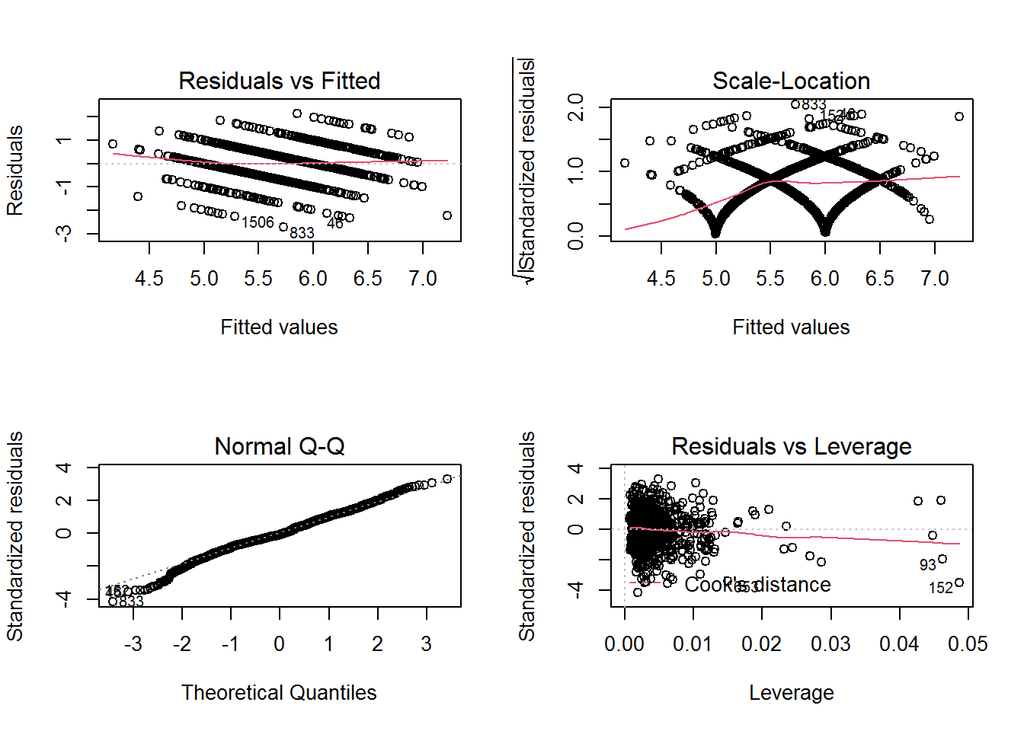

```r
layout(matrix(c(1,2,3,4),2,2))
plot(modelo2)
```

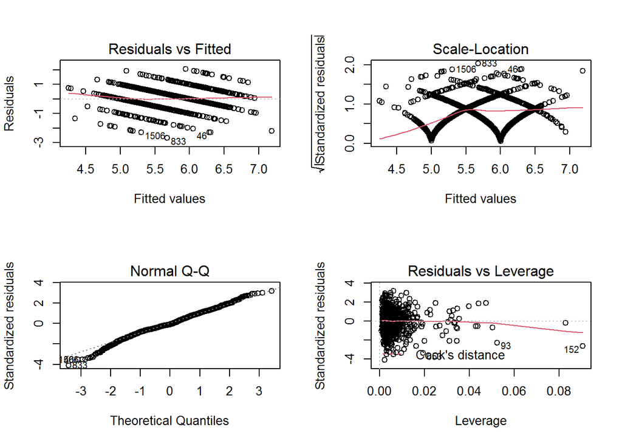

```r
layout(matrix(c(1,2,3,4),2,2))
plot(modelo3)
```

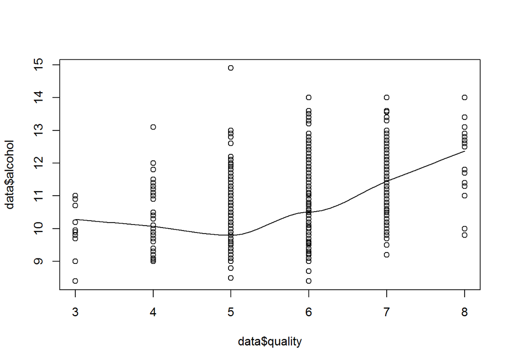

```r
# Con las siguientes representaciones, nos hacemos una idea de cómo se comportan las variables alcohol,volatile.acidity, sulphates, citric.acid, total.sulfur.dioxide y density, en relación con la calidad del vino
scatter.smooth(data$quality, data$alcohol)
```

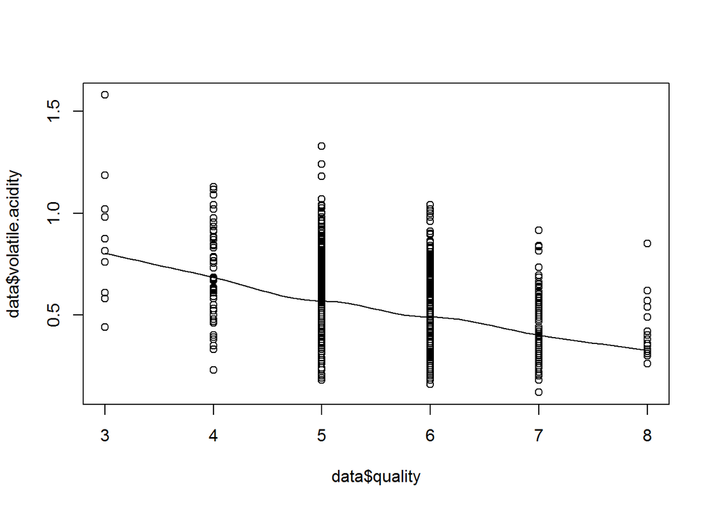

```r
scatter.smooth(data$quality, data$volatile.acidity)
```

[figure not shown]

```r
scatter.smooth(data$quality, data$sulq)
```

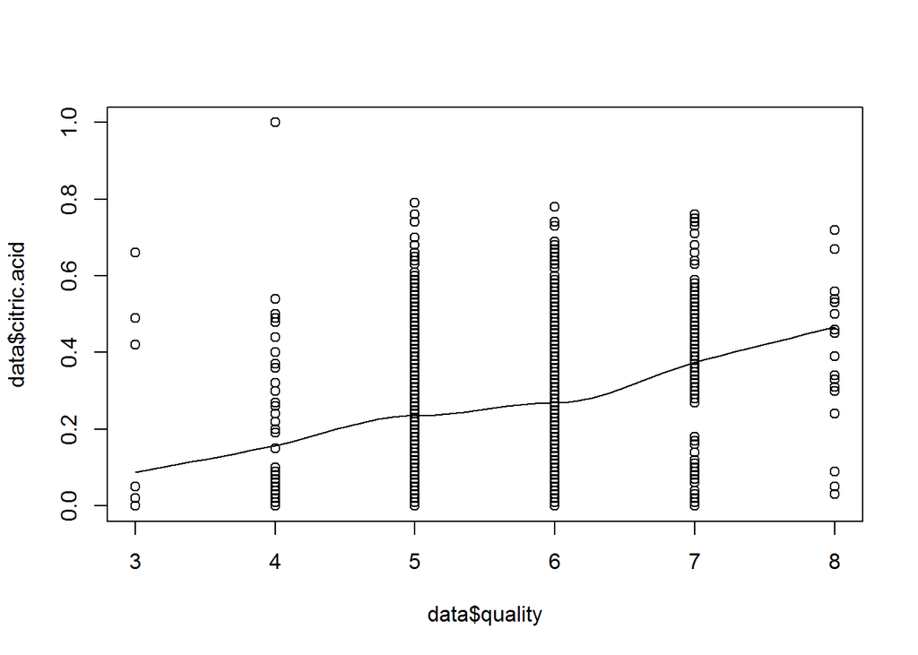

```r
scatter.smooth(data$quality, data$citric.acid)
```

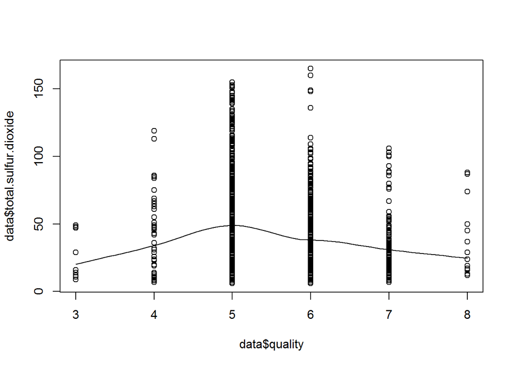

```r
scatter.smooth(data$quality, data$total.sulfur.dioxide)
```

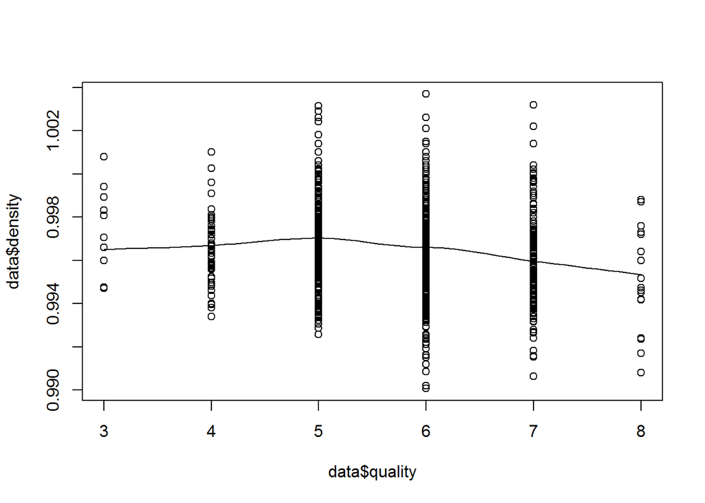

```r
scatter.smooth(data$quality, data$density)
```

Realizamos una tabla de comparación entre los modelos lineales implementados.

```r
# Tabla con los coeficientes de determinación de cada modelo
tabla.coeficientes <- matrix(c(
1, summary(modelo1)$r.squared,
2, summary(modelo2)$r.squared,
3, summary(modelo3)$r.squared), ncol = 2, byrow = TRUE)
colnames(tabla.coeficientes) <- c("Modelo", "R^2")
tabla.coeficientes
```

```
##      Modelo       R^2
## [1,]      1 0.3361393
## [2,]      2 0.3438525
## [3,]      3 0.3516932
```

Se observa que el modelo lineal 3 es ligeramente mejor que sus predecesores.

```r
exp(cbind(coef(model.logist1),confint(model.logist1)))
```

```
##                                          2.5 %       97.5 %
## (Intercept)          2.064915e-04 3.704236e-05 1.103863e-03
## alcohol              2.473523e+00 2.157031e+00 2.851013e+00
## volatile.acidity     2.990667e-02 1.217130e-02 7.148419e-02
## sulphates            1.847251e+01 7.840845e+00 4.438928e+01
## citric.acid          4.106158e-01 1.894415e-01 8.832982e-01
## chlorides            1.649255e+00 1.269212e-02 1.944006e+02
## total.sulfur.dioxide 9.878187e-01 9.838110e-01 9.917551e-01
```

```r
#install.packages("caret")
#install.packages("e1071")

#Import required library
library(caret)
```

Estimación de la precisión del modelo logistico Vamos a proporcionar la tabla de confusión correspondiente al modelo.

Se adopta como criterio que las predicciones obtenidas con el modelo logístico por encima de 0,5 pertenecerían al grupo de calidad alta. Anteriormente hemos definido: CalidadAlta será igual a 1 cuando los valores de la variable quality sean superiores o iguales a 6

```r
confusionMatrix(table(predict(model.logist1, type="response") >= 0.5,data$CalidadAlta == "1"))
```

```
## Confusion Matrix and Statistics
##
##
##         FALSE TRUE
##   FALSE   539  213
##   TRUE    205  642
##
##                Accuracy : 0.7386
##                  95% CI : (0.7163, 0.76)
##     No Information Rate : 0.5347
##     P-Value [Acc > NIR] : <2e-16
##
##                   Kappa : 0.475
##
##  Mcnemar's Test P-Value : 0.7321
##
##             Sensitivity : 0.7245
##             Specificity : 0.7509
##          Pos Pred Value : 0.7168
##          Neg Pred Value : 0.7580
##              Prevalence : 0.4653
##          Detection Rate : 0.3371
##    Detection Prevalence : 0.4703
##       Balanced Accuracy : 0.7377
##
##        'Positive' Class : FALSE
##
```

Se obteniene de esta manera que el modelo logístico tiene una precisión superior al 70%.

## 6. Resolución del problema. A partir de los resultados obtenidos, ¿cuáles son las conclusiones? ¿Los resultados permiten responder al problema?

En el preprocesamiento de los datos valores extremos (outliers), se han utilizado los siguientes criterios adoptados según las variables del conjunto de datos: -residual.sugar: Se decide que los valores por encima de 10 van a ser considerados outliers. -chlorides: se decide considerar outliers a los valores superiores a 0,3 -free.sulfur.dioxide: se decide considerar outliers los valores por encima de 60. -total.sulfur.dioxide: se considerar outliers los valores por encima de 170. -sulphates: se decide considerar outliers los valores por encima de 1,5.

A todos esos casos se ha decidido imputar el valor de la mediana, exluidos los casos considerados outliers.  
En el resto de variables. no se han realizado modificaciones de los datos.

De análisis de los datos, podemos indicar que:

Del contraste de hipotesis realizado, la calidad de los vinos es diferente entre los considerados como nivel bajo de alcohol y nivel alto, con un nivel de confianza del 95%. Por lo observado, parece que el nivel de calidad puede ser superior para los vinos con un nivel alto de alcohol.

Adicionalmente hemos realizados diferentes modelos de regresión, lineales y logística, que serían útiles para realizar predicciones sobre la calidad dadas unas características concretas, de las otras variables.

De lo anterior podemos indicar que del análisis de los datos podemos aclarar cómo algunas de las variables del conjunto de datos están relacionadas con el problema planteado, conocer la calidad del vino.

## 7. Código: Hay que adjuntar el código, preferiblemente en R, con el que se ha realizado la limpieza, análisis y representación de los datos. Si lo preferís, también podéis trabajar en Python.

#exportacion de datos tras el tratamiento:

```r
write.csv(data,"C:\\Users\\Usuario\\winquality_modificado.csv", row.names = FALSE)
```